# Coursework Report

*N* removed NAs: 2

*N* removed typo: 1

*N* removed <18: 28

[output not shown]

**Main analysis results**

[interactive chart not shown]

[figure not shown]

[interactive chart not shown]

# Coursework Report

Analysing Data, Spring 2020

This student has a record of specific learning difficulty (dyslexia/dyspraxia). Please mark this report in accordance with the [marking guidelines for SLD](https://www.sussex.ac.uk/studentsupport/staff/spld?fbclid=IwAR2lYKD6xvuv9egQDvG8d_oed9GUD3KXQn3gAdlHZ1gQB8gDddBdeOEmKdE).

[output not shown]

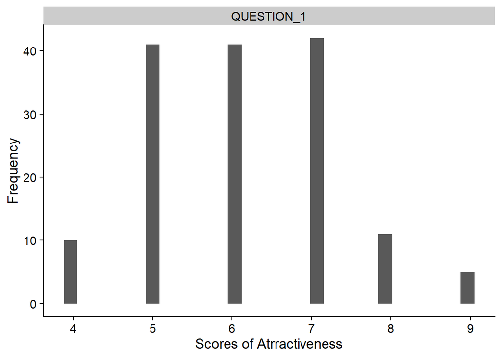

[output not shown]

[figure not shown]

[output not shown]

| GROUP | n | perc | mean_qc | sd_qc |
| --- | --- | --- | --- | --- |
| White Frame Group | 80 | 53.33333 | 5.995833 | 0.7145145 |
| Red Frame Group | 70 | 46.66667 | 6.257143 | 0.6010496 |

Table 1: Descriptive statistics showing Condition Type and Average Rating of Attractiveness

| Condition | Number of Ppts | Percentage(%) | Mean Score of Atrractiveness | Standard Deviation |
| --- | --- | --- | --- | --- |
| White Frame Group | 80 | 53.33 | 6.00 | 0.71 |
| Red Frame Group | 70 | 46.67 | 6.26 | 0.60 |

# Methods

## Participants

Figure 1: Descriptive statistics of ages of participants

| Condition | Number of Ppts | Percentage(%) | Mean Age | Standard Deviation of Age |
| --- | --- | --- | --- | --- |
| White Frame Group | 80 | 53.33 | 20.04 | 2.25 |
| Red Frame Group | 70 | 46.67 | 19.09 | 3.07 |

## Design

The aim of this study was to explore whether the colour red increased ratings of attractiveness of a male (in this case in the form of a red frame). The alternative hypothesis was: ‘There will be a significant increase in ratings of attractiveness when image of a male is displayed to participants in a red frame, compared to ratings of attractiveness when image of a male is displayed to participants in a white frame’. The null hypothesis was: ‘There will be no difference in ratings of attractiveness between both red frame and white frame conditions, when an image of a male is presented to participants’. There were 3 questions participants were required to answer during the study in relation to being showed a black and white portrait photo of a man with a neutral expression presented in a red frame (the experimental condition) and a black and white portait of a man presented in a white frame (the control condition). Participants were made aware that the aim of the study was to investigate individual’s first impressions of others. The frame used to display the male target was a between-subject colour condition, as participants would be exposed to only one colour condition, however, the male target displayed to each participant was a standardised image. The individual variable was the colour frame used to display the image to the participants, and was a factor in contributing to the ratings of attractiveness. The control variable in the study is the image of the male used to display to the participants who rate the levels of attractiveness, the image was consistent across conditions and printed in the same size and black and white colour.. Finally, the dependant variables were the ratings of attractiveness reflected in Questions 1,2 and 3. The perceived attractiveness was measured using 3 questions: Question 1: ‘How attractive do you think this person is?’, Question 2: ‘How pleasant is this person to look at?’, and Question 3: ‘If I were to meet this person face to face, I would think he is attractive.’ The possible answers to each question were rated on a 9 point scale, ranging from 1 (meaning ‘not attractive at all’), to 9 (meaning ‘extremely attractive’). Therefore, the operational hypothesis is: ‘Mean rating of attractiveness drawn from questions 1,2 and 3 on a scale ranging from 1 (not attractive), to 9 (very attractive), will be significantly higher when an image of a male is displayed to participants in a red frame, than the mean rating of attractiveness when an image of a male is displayed to participants in a white frame’.

In order to evaluate whether the alternative or null hypothesis should be accepted, I will first create a composite score of the three rating variables in both conditions, then, create a plot comparing these two composite scores against colour condition.After this, I will use the T-test to determine the degree of significance between the means of the conditions.

# Results

I did a correlation matrix of questions 1, 2 and 3 in order to if there was a pattern in responses to all the questions.

```
##            QUESTION_1 QUESTION_2 QUESTION_3
## QUESTION_1       1.00      -0.11      -0.06
## QUESTION_2      -0.11       1.00      -0.11
## QUESTION_3      -0.06      -0.11       1.00
##
## n= 150
##
##
## P
##            QUESTION_1 QUESTION_2 QUESTION_3
## QUESTION_1            0.1880     0.4632
## QUESTION_2 0.1880                0.1640
## QUESTION_3 0.4632     0.1640
```

Using the mean rating of attractiveness and standard deviations of them, grouped by condition, I created a plot showing the difference in mean ratings of attractiveness in both the control group (White Frame Group) and the experimental condition (Red Frame Group) and the standard deviations, allowing us to evaluate the spread of the data.

I was able to find the composite score of the three ratings, the mean attractiveness score of the two groups is shown in Figure 2. The means show a slightly higher rating of attractiveness in the experimental condition compared to the control condition. From this it can be learned that the Red Frame Condition has a small impact on perceived attractiveness compared to the White Frame Condition. The standard deviation of the ratings is relatively low as both coefficient values are significantly less than 1. Therefore, the data is overall fairly close to the mean and there is not a high degree of variance. The standard deviation of the ‘White Frame Group’ is higher than the ‘Red Frame Group’, therefore the ratings in the control condition are more spread and further from the mean compared to the experimental condition.

Figure 2: Mean Ratings of Attractiveness by Experimental Condition

| Condition | Mean Rating of Attractiveness | Standard Deviation of Ratings of Attractiveness |
| --- | --- | --- |
| White Frame Group | 6.00 | 0.71 |
| Red Frame Group | 6.26 | 0.60 |

The histogram below (Figure 3) shows the composite ratings of attractiveness from questions 1, 2 and 3 and reflects the distribution of the scores. From this we can learn that most common scores of attractiveness lie within scores of 5-7.

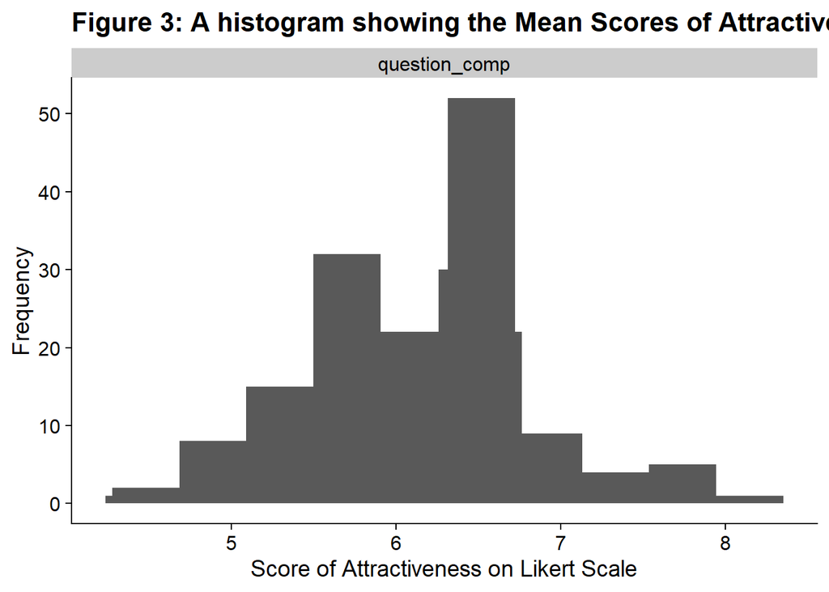

[figure not shown]

```
##
##  Two Sample t-test
##
## data:  question_comp by GROUP
## t = -2.4044, df = 148, p-value = 0.01743
## alternative hypothesis: true difference in means is not equal to 0
## 95 percent confidence interval:
##  -0.47607011 -0.04654893
## sample estimates:
## mean in group White Frame Group   mean in group Red Frame Group
##                        5.995833                        6.257143
```

# Discussion

When interpreting these results, it important to acknowledge other research and consider any methodological issues that may question the validity.

In addition to this, there is a lack of internal validity within the study. The level of which someone is attracted to another person has many different factors which contribute to someone’s overall attractiveness to others, for example, scent, hormonal effects, personality and importantly personal preference all contribute to the ways in which individuals become physically and emotionally attracted to one another. Therefore, it is hard to assess an accurate level of attraction based on simply one black and white image of a male. In obtaining a numerical rating of attractiveness through 3 questions based on a first impression of a black and white image cannot accurately convey a realistic account of attraction. Therefore, it is hard to be sure that what you are measuring in the rating is someone’s attraction and not what society or external influences deem as attractive.

Furthermore, using only numerical values in order to rate someone’s attractiveness may cause issues in the external validity of the findings. Using a likert scale of 1-9 gives very limited information into the depth and aspects of attraction, making it a very reductionist way of collecting data. This is because it reduces a feeling or opinion down to one numerical value, which can undervalue or inaccurately portray the answer In addition to this, the likert scale is vulnerable to biases related to the option of numbers instead of spoken answers. For example, it is often seen in numerical likert scales where the participant will avoid answering the question by choosing the middle number which doesn’t accurately reflect their feelings and opinions. In addition to this repetion is more likely, whereby the participant will be more likely to choose the same number for each question subconsciously despite a disagreement in this value.

Implications of this research may effect society if published, therefore it is important to evaluate these possible implications. The fact that there is weak evidence to support the red effect may be used or accentuated in commercialisation of male products. For example, aftershaves or clothing for males or even replicating enhanced attractiveness in items to be purchased by women, making them more deisrable.

# References

Elliot, A., Kayser, D., Greitemeyer, T., Lichtenfeld, S., Gramzow, R., & Maier, M. (2010). Red, Rank and Romance in Women Viewing Men—Journal of Experimental Psychology: General. American Psychological Association, Inc, 139(3), 399–417.

Peperkoorn, L. S., Roberts, S. C., & Pollet, T. V. (2016). Revisiting the Red Effect on Attractiveness and Sexual Receptivity: No Effect of the Color Red on Human Mate Preferences—Evolutionary Psychology. 14(4), 1–13. https://doi.org/10.1177/1474704916673841